# Lab4_t-test

Tatum Katz, Sam Sambado

1/24/2021

Biometry, EEMB 146, Week 4

# BACKGROUND

## 1. Getting started

All of the datasets you need for this tutorial and your exercises are included in the Lab 4 folder on Gauchospace. The *homework* for you to turn in are at the end of this tutorial. **Please only turn in homework questions 1-2. Do not include the exercises, or anything else, in your homework file this week.** It is highly recommend that you take the time to read the background for this lab and understand it because these concepts and exercises will be a major portion of your final project.

Here is what you need to do to get started:

- Create an R project for lab 4. This will create a folder for lab 4 that you will fill with all of the data and files for this week’s lab:
  - In R Studio, click *File - New Project*
  - A “New Project Wizard” will pop up:
  - Select **New Directory** then **New Project**
  - Name your project *lab_4* or something similar and choose a location to store this
  - A new folder should appear named *lab_4* and it will contain a file called *lab_4.Rproj*.If you close R Studio, you can re-enter this project by clicking on that file
- Save all the files for Lab 4 in your *lab_4* folder.

## 2. Motivation for this lab

When we do statistical tests in ecology we often are comparing the means between two or more samples after accounting for any number of factors or covariates.

For example, think about the plant data from Lab 3. One potential question is: Are mean dandelion rosette diameters significantly different at 3m from the habitat edge compared to 0m? What about 6m compared to 0m?

In both these cases we are interested in the sample means. Therefore, we need to be concerned about the distribution of these sample means. **By making a histogram of these means we could determine their distribution**. If this distribution was normal, we could apply many of the standard statistical tests to our dataset, which have high statistical power (i.e. low Type II error). If this distribution was non-normal we would have to either transform our data or use non-parametric statistics, which would lower our statistical power.

This is really important in ecology because often our data is far from normal. Based on the Central Limit Theorem, we should be able to use standard statistical tests if our sample size is large enough. In this lab we will learn how to determine if our distributions are normal and then apply the appropriate statistical tests to compare means.

## 3. Determine normality of data

### 3.1 Visually with histograms, boxplots, or qqPlots (~new skill alert~)

#### 3.1.1 Visualize with histograms

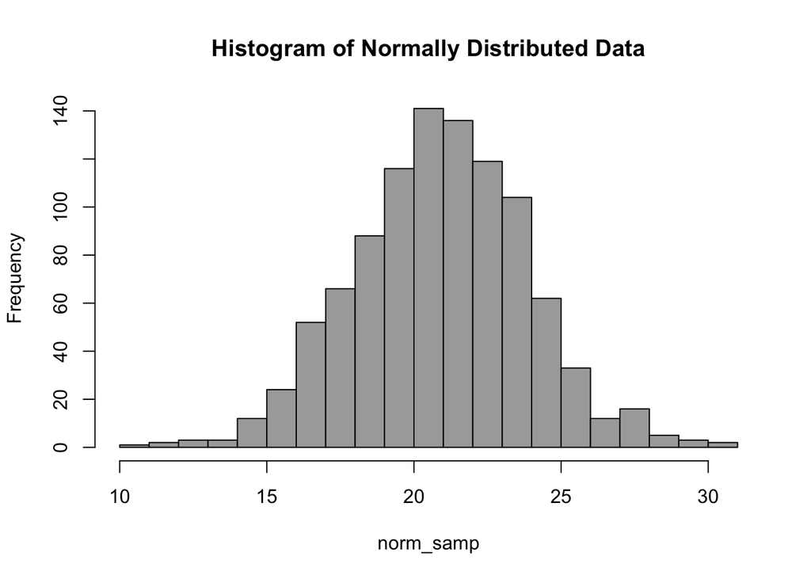

```r
# Make fake data to visualize
norm_samp = rnorm(1000, mean=21 , sd=3) #normal distribution
exp_samp = rexp(1000) #exponential distribution

# Visualization with a Histogram
hist(norm_samp,
     breaks=20, #20 bins is more practical, even though our sample size is 10x bigger. You get a sense of how many fall within bins that have a width that makes sense. This normal variable could be "age" for example
     col='darkgray',
     ylab="Frequency",
     main="Histogram of Normally Distributed Data")
```

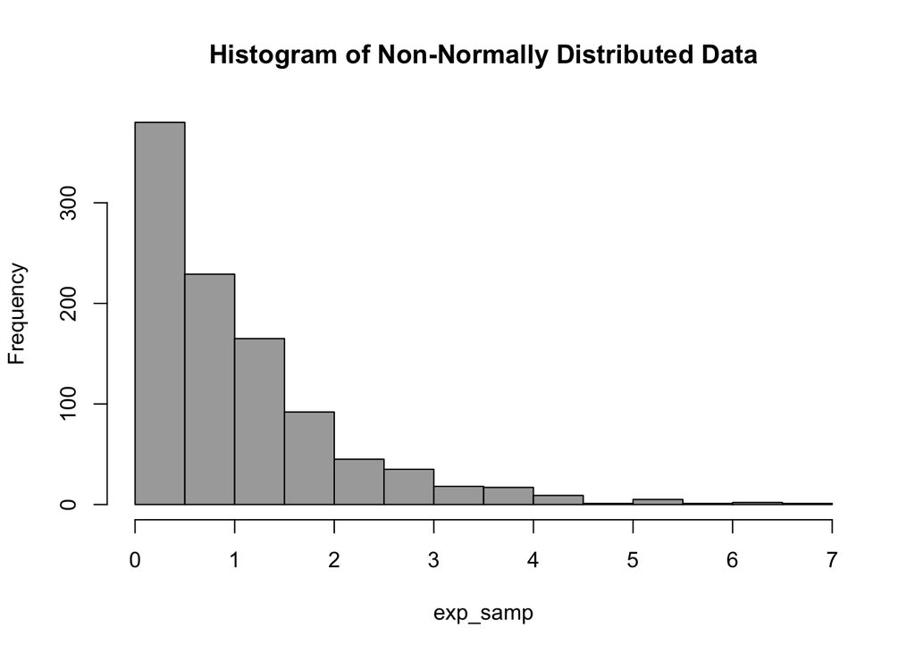

```r
hist(exp_samp,
     breaks=20, #20 bins is more practical, even though our sample size is 10x bigger. You get a sense of how many fall within bins that have a width that makes sense. This normal variable could be "age" for example
     col='darkgray',
     ylab="Frequency",
     main="Histogram of Non-Normally Distributed Data")
```

The `norm_samp` data looks normally distributed The `exp_samp` data does not look normally distributed

#### 3.1.2 Visualize with qqPlots

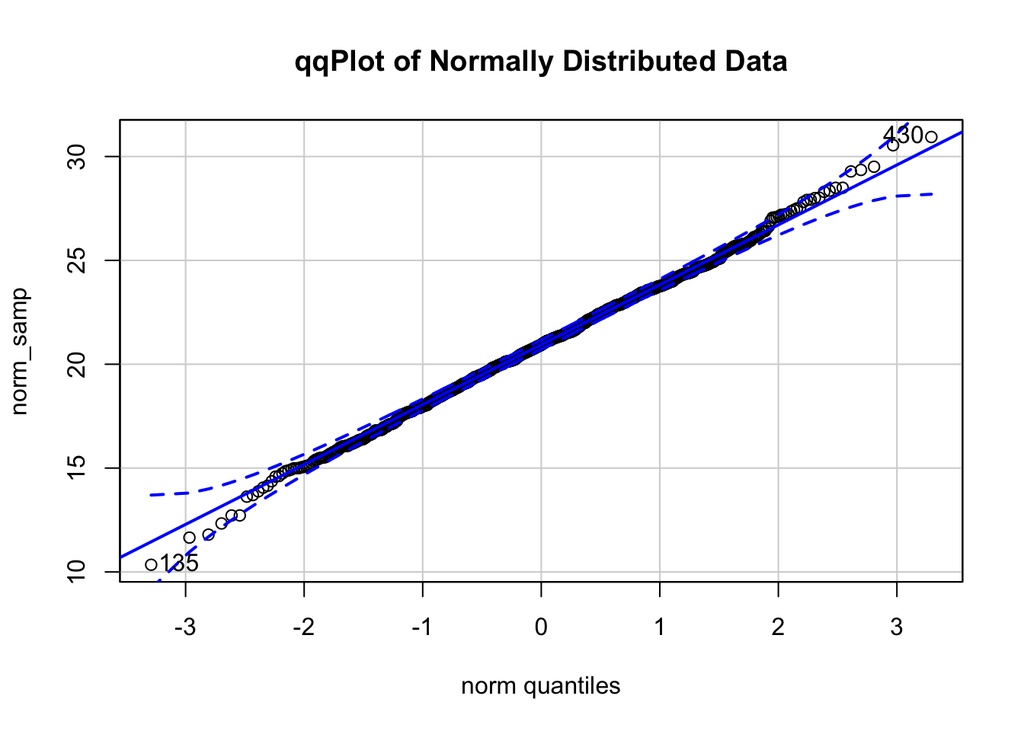

```
## [1] 135 430
```

```r
# Visualization with a qqPlot
#install.packages("car")
#install car package. only run once on each computer. when you knit, #comment this line out
library(car)#load car package

# Now we’ll generate a qqplot using qqPlot function in car package.
qqPlot(norm_samp, main = "qqPlot of Normally Distributed Data") #qqplot function
```

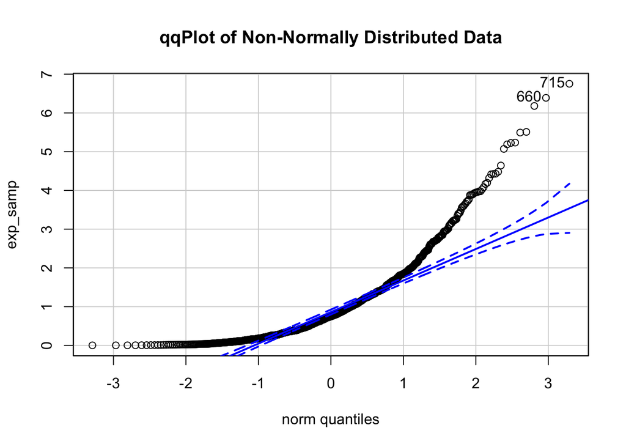

```
## [1] 715 660
```

```r
qqPlot(exp_samp, main = "qqPlot of Non-Normally Distributed Data") #qqplot function
```

For a qqplot, if all of your data points fall in between the dashed confidence bands you can be pretty confident that your data follow a normal distribution.